# Group_A11

# Computer lab 3

Group A11 - Victor Guillo, Christian Kammerer, Jakob Lindner

# Statement of contribution

Assignments 1 and 3 were mainly contributed by Victor Guillo. Christian Kammerer worked on assignment 2 and Jakob Lindner on assignment 4. Results from all assignments have been discussed afterwards between all group members.

# 1 THEORY

## 1 What is the kernel trick?

The kernel trick is a technique in machine learning that allows the use of non-linear models without explicitly transforming the input data into a higher-dimensional space. Instead of directly computing the transformation $\phi(x)$, the kernel function $\kappa(x, x')$ efficiently computes the inner product in the transformed space. This avoids the computational burden of handling the transformed features while enabling non-linear decision boundaries, such as in **Support Vector Machines (SVMs)**. The kernel trick works because models rely only on inner products, which can be replaced by a suitable kernel function. A common example is the Radial Basis Function (RBF) kernel.  
Page 194

## 2 In the literature, it is common to see a formulation of SVMs that makes use of a hyperparameter C. What is the purpose of this hyperparameter?

The hyperparameter C serves as a regularization parameter in the SVM formulation. It controls the trade-off between achieving a low error on the training data and minimizing the norm of the weights. A larger C gives more weight to achieving a low training error, which can lead to a smaller margin but less generalization. A smaller C emphasizes a larger margin at the cost of allowing some misclassifications on the training data. Page 211

## 3 In neural networks, what do we mean by mini-batch and epoch?

A mini-batch is a small, random subset of the training data used to compute the gradient and update the model parameters during one iteration of stochastic gradient descent. It balances computational efficiency and accuracy. An epoch is one complete pass through the entire training dataset. In the mini-batch approach, an epoch consists of multiple iterations, each processing a mini-batch. Pages 124-125

# 2 KERNEL METHODS

We are implementing a kernel method to predict the hourly temperature of a set of coordinates in Sweden, for a given time and date, based on historic temperature records. For this, we are going to use three different kernels which are based on:

1. the haversine distance ($d_{spatial}$), between the given coordinates and the coordinates of the historic records.
2. the distance in day time ($d_{time}$) between the given time and the time of the historic record, by also accounting for the cyclical nature of the clock (00:00 and 23:00 are close to each other, not far).
3. the date distance ($d_{date}$) between the given date and the historic records.

After computing the three different types of distances, we apply the gaussian kernel function with respect to an appropriate smoothing coefficient for the metric.

$$K(d_{var,i}) = \exp\left(-\frac{d_{var,i}^2}{2h_{var}^2}\right), var
\in (spatial, time, date)$$
where $i$ denotes the $i$-th data point and and $h_{var}$ is the smoothing coefficient for the variable var.

```r
kernel_function <- function(distances, h) {
  weights <- lapply(distances, function(distance)
    exp(-(distance ^ 2 / (2 * h ^ 2))))
  return(unlist(weights))
}
```

where $d_{var,j}$ is the distance value of the $i$-th data point w.r.t to the variable $var$ and $h_{var}$ the smoothing coefficient for variable $var$. This gives us the kernel value $K(d_{var,i})$ which acts as a weight of data point $i$ w.r.t $var$.

We then have to aggregate the three different $K(d_{var,i})$ values.

For experiment purposes, we do this in two different fashions, by either summing, or multiplying them.
If summed:
$$w_i = K(d_{spatial,i}) + K(d_{time,i}) + K(d_{date,i})$$
If multiplied:
$$w_i = K(d_{spatial,i}) * K(d_{time,i}) * K(d_{date,i})$$

```r
if (weight_aggregation == "sum") {
    aggregated_weights <- spatial_weights + date_weights + time_weights
  } else if (weight_aggregation == "multiply") {
    aggregated_weights <- spatial_weights * date_weights * time_weights
  }
```

This aggregated weight value determines the weight of the data point in the prediction as shown below.
$$\hat{y} = \frac{\sum_i^n{w_i*y_i}}{\sum_i^n{w_i}}$$

```r
y_hat = sum(aggregated_weights * y) / sum(aggregated_weights)
```

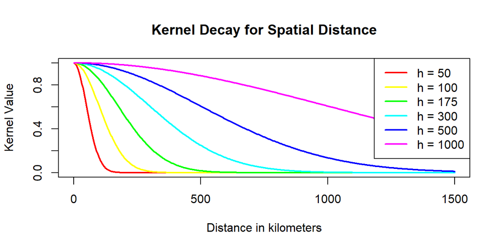

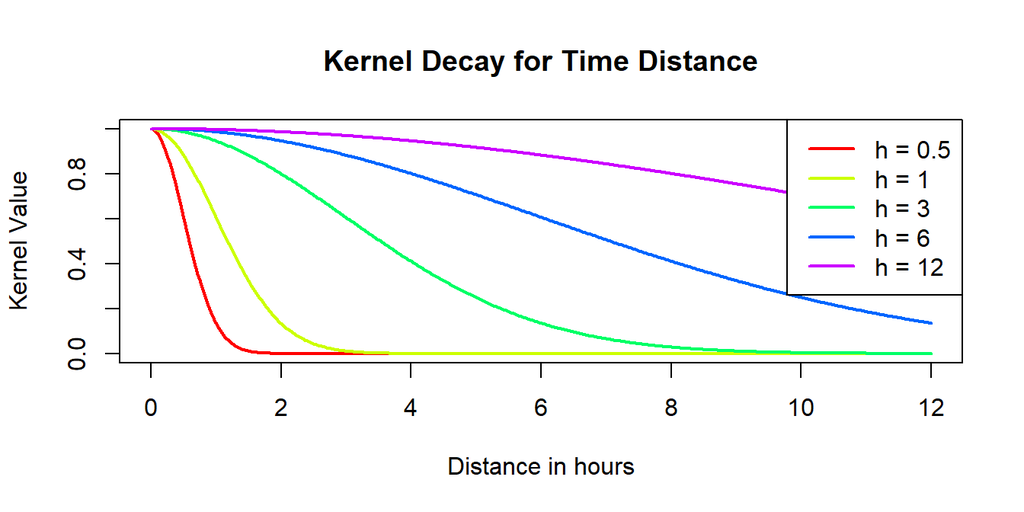

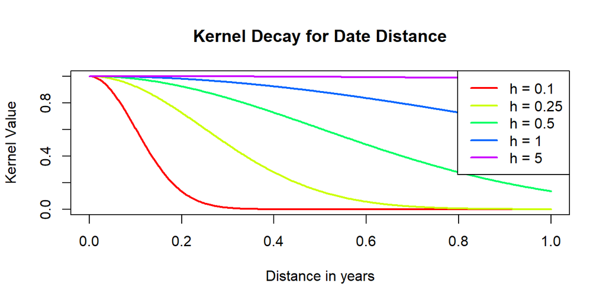

We went with $h_{time} = 3$ (hours), as this somewhat divides a day into quarters (morning, noon, evening, night).

And with $h_{date} = 1/12$ (years) as this corresponds to a month. This means all data points that are over a year old, will be heavily decayed and have almost no influence in the prediction. However, this was necessary, otherwise we would completely lose the seasonal aspect of the weather.

It would make more sense to further break down the date variable to account for seasonal variability and global warming, instead of using it the way we are doing.

## Results

We chose ten random weather stations in Sweden and chose ten random points in time, for which we could find temperature data and compared the real life data to our predictions.

Predictions with Kernel Sum

| Location | Date | Time | Predicted_Temperature | Actual_Temperature | Deviation |
| --- | --- | --- | --- | --- | --- |
| Bromma Airport | 1999-01-08 | 05:00:00 | 3.93 | -5 | -8.93 |
| Linköping Airport | 2012-03-13 | 06:00:00 | 4.17 | 5 | 0.83 |
| Arlanda Airport | 2001-07-13 | 04:00:00 | 3.85 | 13.9 | 10.05 |
| Gothenburg Airport | 2004-09-04 | 20:00:00 | 4.56 | 15 | 10.44 |
| Luleå Airport | 2014-03-19 | 02:00:00 | 2.98 | -11 | -13.98 |
| Malmö Airport | 2011-05-29 | 08:00:00 | 5.15 | 12.2 | 7.05 |
| Västerås Airport | 2010-01-25 | 00:00:00 | 3.17 | -8.9 | -12.07 |
| Dalarna Airport | 2015-02-03 | 02:00:00 | 3.11 | -7.8 | -10.91 |
| Kiruna Airport | 2012-12-31 | 08:00:00 | 4.76 | -3.9 | -8.66 |
| Jönköping Airport | 2011-09-09 | 10:00:00 | 5.94 | 15.5 | 9.56 |
| Average absolute deviation | NA | NA | NA | NA | 9.25 |

Predictions with Kernel Multiply

| Location | Date | Time | Predicted_Temperature | Actual_Temperature | Deviation |
| --- | --- | --- | --- | --- | --- |
| Bromma Airport | 1999-01-08 | 05:00:00 | -1.18 | -5 | -3.82 |
| Linköping Airport | 2012-03-13 | 06:00:00 | -0.01 | 5 | 5.01 |
| Arlanda Airport | 2001-07-13 | 04:00:00 | 12.31 | 13.9 | 1.59 |
| Gothenburg Airport | 2004-09-04 | 20:00:00 | 16.63 | 15 | -1.63 |
| Luleå Airport | 2014-03-19 | 02:00:00 | -2.69 | -11 | -8.31 |
| Malmö Airport | 2011-05-29 | 08:00:00 | 7.16 | 12.2 | 5.04 |
| Västerås Airport | 2010-01-25 | 00:00:00 | -3.49 | -8.9 | -5.41 |
| Dalarna Airport | 2015-02-03 | 02:00:00 | -10.66 | -7.8 | 2.86 |
| Kiruna Airport | 2012-12-31 | 08:00:00 | -9.38 | -3.9 | 5.48 |
| Jönköping Airport | 2011-09-09 | 10:00:00 | 16.14 | 15.5 | -0.64 |
| Average absolute deviation | NA | NA | NA | NA | 3.98 |

From the results above we can draw two conclusions:  
The method which leverages the summation is considerably too “cautious”, meaning it’s predictions have a very small range in which they fall, which corresponds roughly to the yearly mean temperature in Sweden.

The method which leverages multiplication performs significantly better, which we can attribute to the fact, that a very low kernel score, for one variable, has a larger effect on the weight of the data point.

# 3 SUPPORT VECTOR MACHINES

```r
# Calculate the best C
best_C <- which.min(err_va) * by
cat("The best C is:", best_C)
```

```
## The best C is: 1.8
```

For the next part we keep the best C for all filters.

```
## err0 is: 0.165
```

```
## err1 is: 0.1672909
```

```
## err2 is is: 0.1498127
```

```
## err3 is is: 0.01373283
```

Filter 0 : Verify how well the SVM model with the best C performs on the validation set. err0 helps validate the tuning of C.

Filter 1 : Measure the generalization error of the model on unseen data (test set). err1 shows into how well the model performs outside the validation set.

Filter 2 : By using more data (training + validation), the model has a potentially stronger fit. err2 tests whether this improved training size leads to better generalization on the test set.

Filter 3 : Train the final model using all available data, maximizing the information for training. Evaluate on the test set to observe the generalization error.

### Questions

err0: Measures error on the validation set (va), which was only used to tune C. It does not estimate the model’s performance on unseen data. err1: Measures error on the test set (te), but the model is trained only on 3000 training samples, not the full dataset. err2: Measures error on the test set (te), but the model is trained on 3800 samples (trva), which is larger than filter1, but still smaller than the entire dataset. err3: Measures error on the test set (te), and since filter3 is trained on all 4601 samples, this is the best and most reliable model for generalization.

3. SVM Decision Function

The SVM decision function is defined as:

$$f(x) = \sum_{i=1}^{N} \alpha_i K(x_i, x) + b$$

Where:

- $\alpha_i$ are the coefficients for the support vectors,
- $K(x_i, x)$ is the kernel function,
- $b$ is the intercept term.

The **RBF kernel** is given by:

$$K(x, x') = \exp\left(-\frac{\|x - x'\|^2}{2\sigma^2}\right)$$

Here: - $\|x - x'\|^2$ is the squared Euclidean distance between two points $x$ and $x'$, - $\sigma$ is the kernel width parameter

```r
# Extract support vector indices, coefficients, and intercept
sv <- alphaindex(filter3)[[1]] # Support vector indices
co <- coef(filter3)[[1]]       # Coefficients for the support vectors
inte <- -b(filter3)            # Negative intercept

# Initialize a vector to store the decision values
k <- NULL

# Compute decision values for the first 10 points
for (i in 1:10) {
  k2 <- NULL # Initialize contributions for the current data point
  for (j in 1:length(sv)) {
    # Compute the RBF kernel value between point i and support vector j
    diff <- as.numeric(spam[i, -58] - spam[sv[j], -58]) # Difference between features
    rbf_kernel <- exp(-sum(diff^2) / (2 * 0.05^2))      # RBF kernel computation
    k2 <- c(k2, co[j] * rbf_kernel)                    # Contribution from support vector j
  }
  # Compute final decision value for data point i
  k <- c(k, sum(k2) + inte)
}

# Output the computed decision values
k
```

```
##  [1]  0.006292512  0.457293502  0.854669625 -0.730198576 -0.860385532
##  [6]  0.404159399 -1.793707488 -0.674704164  0.576064455 -0.964727603
```

```r
# Compare the computed decision values with predict()
predict(filter3, spam[1:10, -58], type = "decision")
```

```
##             [,1]
##  [1,] -1.0702965
##  [2,]  1.0003450
##  [3,]  0.9995908
##  [4,] -0.9999648
##  [5,] -0.9995379
##  [6,]  1.0000612
##  [7,] -0.8585873
##  [8,] -0.9997047
##  [9,]  0.9998209
## [10,] -1.0000973
```

Positive value: The point is classified as belonging to the positive class. Negative value: The point is classified as belonging to the negative class.

# 4 NEURAL NETWORKS

## Task 1

We used the given code template to create the dataset containing 500 points in the interval [0,10], to split it in training and test data and to train the neural network with 10 hidden units. For the start weights we sampled ten random values between -1 and 1.

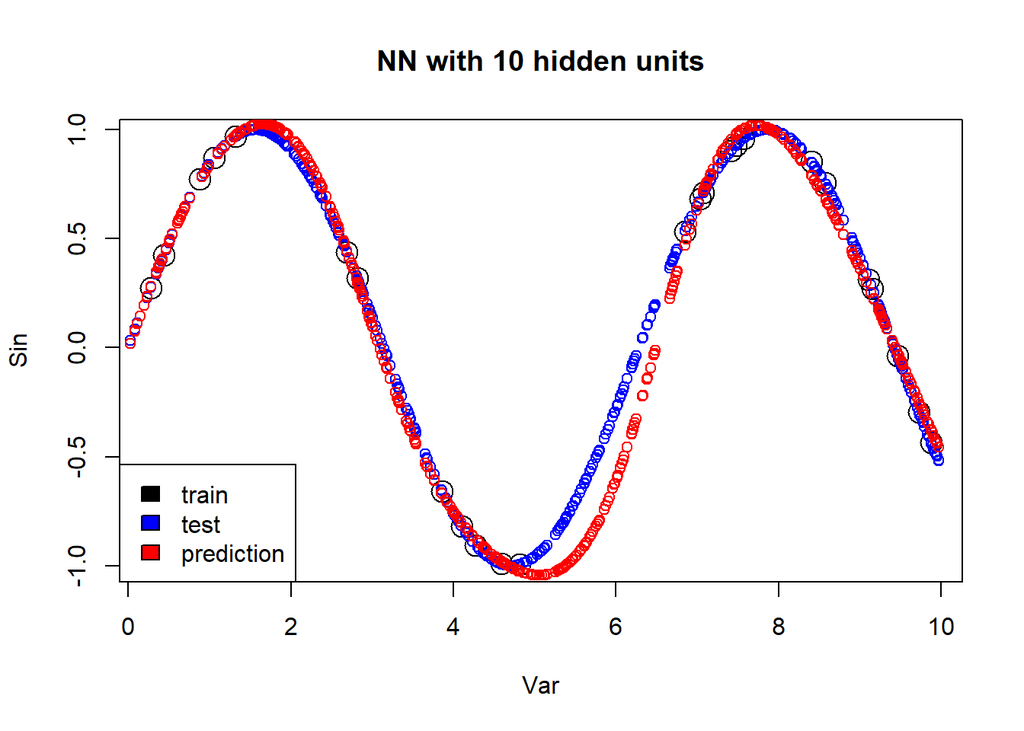

```r
set.seed(1234567890)
# create data
Var <- runif(500, 0, 10)
mydata <- data.frame(Var, Sin=sin(Var))
# split data
train <- mydata[1:25,]
test <- mydata[26:500,]
# Random initialization of the weights in the interval [-1, 1]
set.seed(1234567890)
winit <- runif(10,-1,1)

# train data with one hidden layer and 10 hidden units
nn <- neuralnet(Sin~Var, train, hidden=10, startweights=winit)

# Plot of the training data (black), test data (blue), and predictions (red)
plot(train, cex=2)
points(test, col = "blue", cex=1)
points(test[,1],predict(nn,test), col="red", cex=1)
title("NN with 10 hidden units")
legend(x="bottomleft", legend=c("train", "test","prediction"), fill=c("black","blue", "red"))
```

The overall prediction quality is good. Between approximately Var = 5 and Var = 6.5 it is a little bit off though. This might be explained by the missing training data in this interval.

## Task 2

The linear activation function, ReLU and softplus are implemented and used for three different neural nets. For ReLU we used the “ifelse” construct , as the max()-function is not differentiable and causes an error in the training.

```r
h1 <- function(x) x
h2 <- function(x) ifelse(x > 0, x, 0)
h3 <- function(x) log(1+exp(x))

nn_h1 <- neuralnet(Sin~Var, train, hidden=10, act.fct=h1, startweights=winit)
nn_h2 <- neuralnet(Sin~Var, train, hidden=10, act.fct=h2, startweights=winit)
nn_h3 <- neuralnet(Sin~Var, train, hidden=10, act.fct=h3, startweights=winit)
```

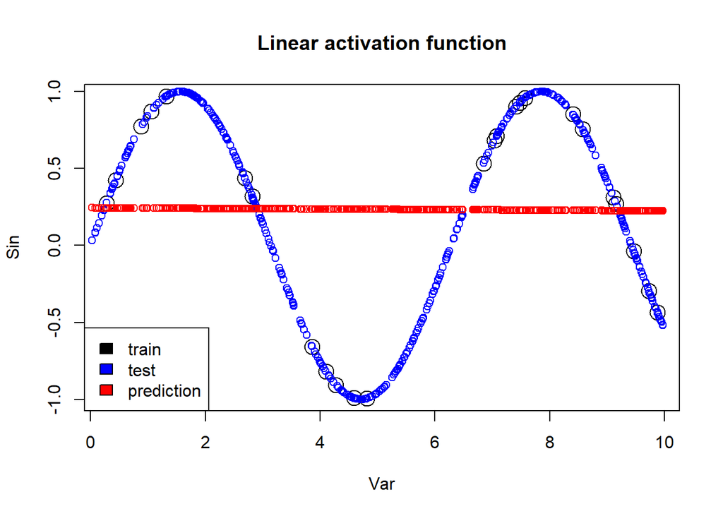

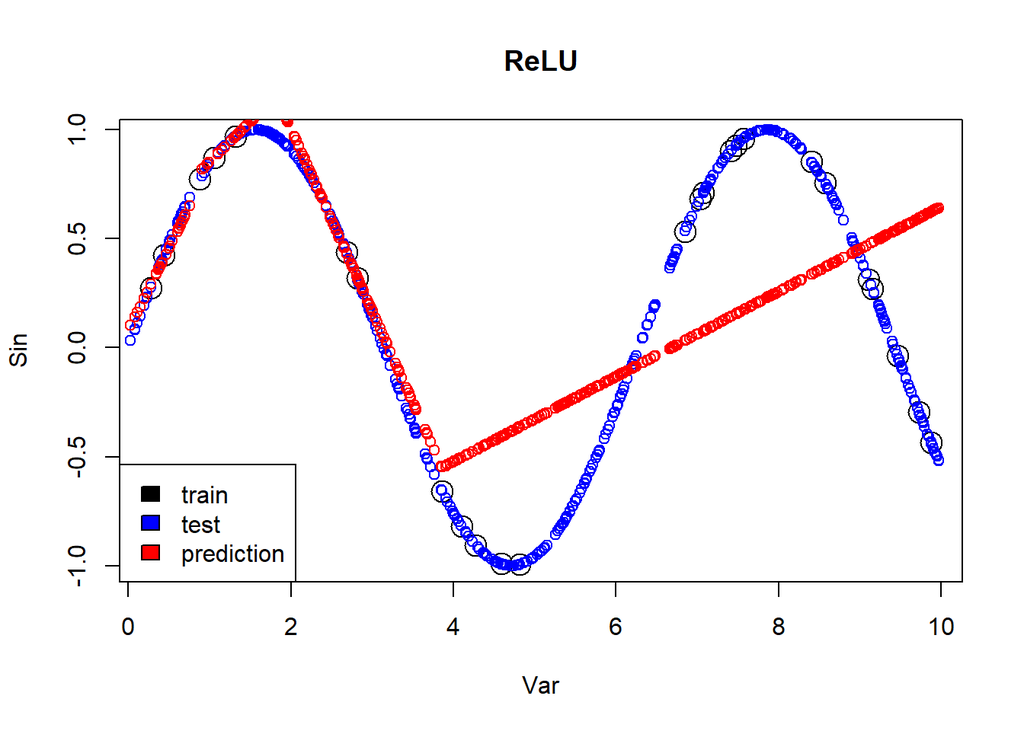

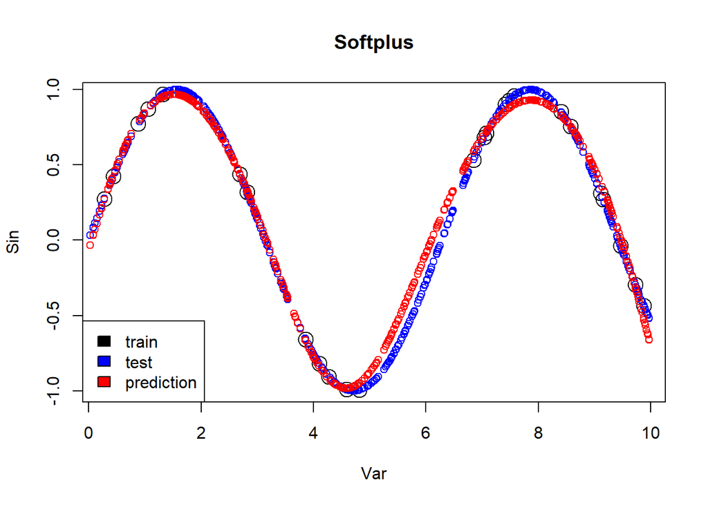

For the linear activation function the underlying pattern is not learned at all. This is not surprising as it does not add any non-linearity.

Using ReLU as activation function results in a slightly better prediction. But from Var=4 on it is just a linear line. Reasons for that might be that ReLU is still piece wise linear and the model does not have enough neurons to adjust to the non-linear sinus function.

The results of the neural net with softplus are similar to the net with sigmoid. But the interval where the predictions are a bit further from the actual values is a bit bigger for softplus, roughly from Var = 5 to Var = 8.5.

## Task 3

For this task we need a new dataset with 500 points, but in the range from 0 to 50.

```r
# create new data
set.seed(1234567890)
Var <- runif(500, 0, 50)
mydata_3 <- data.frame(Var, Sin=sin(Var))
```

Then the neural network from task 1 is used to predict the sinus on the new data.

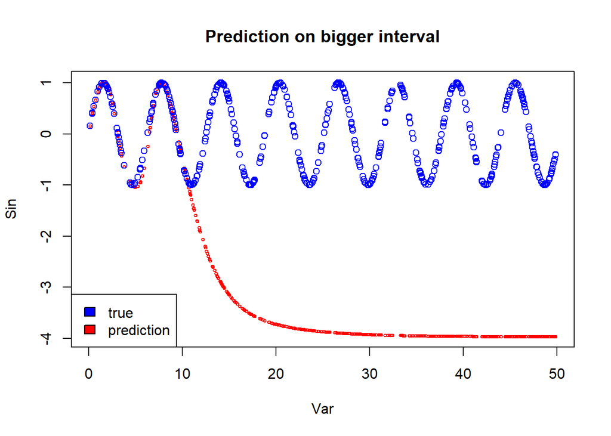

In the interval, that the net was trained for, the prediction is very good. But for Var > 10 the prediction converges towards -3.97.

```
## Minimum value of prediction: -3.969336
```

## Task 4

As there is no training data for values bigger than 10, the prediction fails for these. But why it converges to this exact value is not clear. We cannot find any indicator in the weights:

```
## Weights for input to hidden layer: 11.513 4.272 -0.8795 -0.8276 5.5674 0.2863 0.2569 0.9651 -0.5697 1.6987
```

```
## Weights for bias to hidden layer: -1.7517 -0.4719 -0.1691 -0.8734 -1.9694 0.1537 0.8253 0.1511 -0.1557 -0.6942
```

```
## Weights for output layer: 0.5203 -4.7498 6.6557 2.9049 -6.7634 2.3065 -3.5924 0.6954 -1.5948 0.7492 -1.0623
```

As the hidden layers are “black boxes” that cannot be explained by humans in most cases, this is not surprising.

### Task 5

The same procedure as for the previous tasks is used here as well. Only the target and feature variables are switched to predict x from sin(x).

```r
set.seed(1234567890)
Var <- runif(500,0,10)
mydata_5 <- data.frame(Var, Sin=sin(Var))

nn5 <- neuralnet(Var~Sin, mydata_5, hidden=10, threshold=0.1, startweights=winit)
```

[figure not shown]

The results are very bad. The predictions are not close to the actual value at all, which makes sense as many x values result in the same sin(x).

# Appendix

```r
## Assignment 2

set.seed(1234567890)
library(geosphere)

# Data preprocessing
stations <- read.csv("stations.csv", fileEncoding = "latin1")
temps <- read.csv("temps50k.csv")
st <- merge(stations, temps, by = "station_number")
# st$coords <- apply(st, 1, function(row) list(c(row['longitude'], row['latitude'])))
st <- subset(st, select = c(latitude, longitude, date, time, air_temperature))
st$date <- as.Date(st$date)
st$time <- strptime(st$time, format = "%H:%M:%S")


# Decay values
h_distance <- 50
h_date <- 1/12
h_time <- 3

calc_spatial_distance <- function(coords_matrix, coords_target) {
  # Calculate absolute distance in km
  distances = apply(coords_matrix, 1, function(coord)
    distHaversine(coord, coords_target))
  abs_km_distances = abs(distances) / 1000
  return (abs_km_distances)
}

calc_date_distances <- function(date_list, date_target) {
  # Calculate absolute distance in years
  distances = lapply(date_list, function(date)
    difftime(date, date_target, units = "days"))
  num_abs_distances = abs(as.numeric(distances) / 365)
  return(num_abs_distances)
}

calc_time_distances <- function(time_list, time_target) {
  # Calculate absolute distance accounting for 24-hour day cycle (23 o'clock and 1 o'clock are close not far)
  distances = lapply(time_list, function(time)
    min(abs(
      difftime(time, time_target, units = "hours")
    ), 24 - abs(
      difftime(time, time_target, units = "hours")
    )))
  num_distances = as.numeric(distances)
  return(num_distances)
}

kernel_function <- function(distances, h) {
  weights <- lapply(distances, function(distance)
    exp(-(distance ^ 2 / (2 * h ^ 2))))
  return(unlist(weights))
}


predict_temp <- function(data,
                         coords,
                         date,
                         time,
                         weight_aggregation) {
 print(coords)
  data <- data[data$date < date, ] # filter for only prior data points
  coords_matrix <- cbind(data$latitude, data$longitude) # combine coordinates
  y <- data$air_temperature # extract target variable

  # Calculate distances & weights
  spatial_distances <- calc_spatial_distance(coords_matrix, coords)
  date_distances <- calc_date_distances(data$date, date)
  time_distances <- calc_time_distances(data$time, time)
  spatial_weights <- kernel_function(spatial_distances, h_distance)
  date_weights <- kernel_function(date_distances, h_date)
  time_weights <- kernel_function(time_distances, h_time)

  aggregated_weights <- NULL
  if (weight_aggregation == "sum") {
    aggregated_weights <- spatial_weights + date_weights + time_weights
  } else if (weight_aggregation == "multiply") {
    aggregated_weights <- spatial_weights * date_weights * time_weights
  }
  return(sum(aggregated_weights * y) / sum(aggregated_weights))
}
# Function to plot kernel decay
plot_kernel_decay <- function(min_value,
                              max_value,
                              h_values,
                              units,
                              title = "Spatial Distance") {
  # Define kernel function
  kernel_function <- function(distance, h) {
    exp(-(distance ^ 2) / (2 * h ^ 2))
  }

  # Generate distances based on the provided range
  distances <- seq(min_value, max_value, length.out = 500)

  # Plot setup
  plot(
    distances,
    kernel_function(distances, h_values[1]),
    type = "l",
    lwd = 2,
    col = "blue",
    ylim = c(0, 1),
    xlab = paste("Distance in", units),
    ylab = "Kernel Value",
    main = title
  )

  # Add additional curves for other h values
  if (length(h_values) > 1) {
    colors <- rainbow(length(h_values))
    for (i in seq_along(h_values)) {
      lines(
        distances,
        kernel_function(distances, h_values[i]),
        col = colors[i],
        lwd = 2
      )
    }
    legend(
      "topright",
      legend = paste0("h = ", h_values),
      col = colors,
      lwd = 2
    )
  } else {
    legend(
      "topright",
      legend = paste0("h = ", h_values[1]),
      col = "blue",
      lwd = 2
    )
  }
}

# Example Usage
plot_kernel_decay(
  min_value = 0,
  max_value = 1500,
  h_values = c(50, 100, 175, 300, 500, 1000),
  # Different h values to compare
  units = "kilometers",
  title = "Kernel Decay for Spatial Distance"
)

plot_kernel_decay(
  min_value = 0,
  max_value = 12,
  h_values = c(0.5, 1, 3, 6, 12),
  # Different h values to compare
  units = "hours",
  title = "Kernel Decay for Time Distance"
)

plot_kernel_decay(
  min_value = 0,
  max_value = 1,
  h_values = c(0.1, 0.25, 0.5, 1, 5),
  # Different h values to compare
  units = "years",
  title = "Kernel Decay for Date Distance"
)




dates = c('1999-01-08', # Bromma
         '2012-03-13', # Linköping
         '2001-07-13', # Arlanda
         '2004-09-04', # Gothenburg
         '2014-03-19', # Luleå
         '2011-05-29', # Malmö
         '2010-01-25', # Västerås
         '2015-02-03', # Dalarna
         '2012-12-31', # Kiruna
         '2011-09-09') # Jönköping

coordinates <- list(
  c(59.3544, 17.9415),  # Bromma Airport
  c(58.4062, 15.6805),  # Linköping Airport
  c(59.6519, 17.9186),  # Arlanda Airport
  c(57.6666, 12.2878),  # Gothenburg Airport
  c(65.5490, 22.1232),   # Luleå
  c(55.5366, 13.376),   # Malmö Airport
  c(59.5894, 16.6336),  # Västerås Airport
  c(60.4336, 15.5018),  # Dalarna Airport
  c(67.8210, 20.3368),  # Kiruna Airport
  c(57.7576, 14.0687)   # Jönköping Airport
)

locations <- c(
  "Bromma Airport",
  "Linköping Airport",
  "Arlanda Airport",
  "Gothenburg Airport",
  "Luleå Airport",
  "Malmö Airport",
  "Västerås Airport",
  "Dalarna Airport",
  "Kiruna Airport",
  "Jönköping Airport"
)

times <- c("05:00:00", "06:00:00", "04:00:00", "20:00:00", "02:00:00",
                   "08:00:00", "00:00:00", "02:00:00", "08:00:00", "10:00:00")

actual_temperatures <- c(-5, 5, 13.9, 15, -11, 12.2, -8.9, -7.8, -3.9, 15.5)

# Initialize a data frame to store results
results <- data.frame(
  Location = character(),
  Date = character(),
  Time = character(),
  Predicted_Temperature = numeric(),
  Actual_Temperature = numeric(),
  Deviation = numeric(),
  stringsAsFactors = FALSE
)
```

```r
# Loop to calculate predictions and store results
for (i in seq_along(times)) {
  # Convert date and time
  date <- as.Date(dates[i])
  time <- strptime(times[i], format = "%H:%M:%S", tz = "UTC")

  # Validate coordinate length
  if (length(coordinates[[i]]) != 2) {
    stop(sprintf("Coordinates for %s are invalid: %s", locations[i], coordinates[[i]]))
  }

  # Predict temperature
  y_pred <- predict_temp(
    data = st,
    coords = coordinates[[i]],  # Use [[i]] to extract the vector
    time = time,
    date = date,
    weight_aggregation = "sum"
  )

  # Calculate deviation
  deviation <- actual_temperatures[i] - y_pred

  # Append to results data frame
  results <- rbind(results, data.frame(
    Location = locations[i],
    Date = dates[i],
    Time = times[i],
    Predicted_Temperature = round(y_pred, 2),
    Actual_Temperature = actual_temperatures[i],
    Deviation = round(deviation, 2),
    stringsAsFactors = FALSE
  ))
}

# Save the results to an RDS file for easier loading in R
write.csv(results, "predictions_kernel_sum.csv", row.names = FALSE)


## Assignment 3


library(kernlab)
set.seed(1234567890)

data(spam)
foo <- sample(nrow(spam))
spam <- spam[foo,]
tr <- spam[1:3000, ]
va <- spam[3001:3800, ]
trva <- spam[1:3800, ]
te <- spam[3801:4601, ]

by <- 0.3
err_va <- NULL
for(i in seq(by,5,by)){
  filter <- ksvm(type~.,data=tr,kernel="rbfdot",kpar=list(sigma=0.05),C=i,scaled=FALSE)
  mailtype <- predict(filter,va[,-58])
  t <- table(mailtype,va[,58])
  err_va <-c(err_va,(t[1,2]+t[2,1])/sum(t))
}


best_C <- which.min(err_va) * by
best_C

filter0 <- ksvm(type~.,data=tr,kernel="rbfdot",kpar=list(sigma=0.05),C=which.min(err_va)*by,scaled=FALSE)
mailtype <- predict(filter0,va[,-58])
t <- table(mailtype,va[,58])
err0 <- (t[1,2]+t[2,1])/sum(t)
cat("err0 is:", err0, "\n")

filter1 <- ksvm(type~.,data=tr,kernel="rbfdot",kpar=list(sigma=0.05),C=which.min(err_va)*by,scaled=FALSE)
mailtype <- predict(filter1,te[,-58])
t <- table(mailtype,te[,58])
err1 <- (t[1,2]+t[2,1])/sum(t)
cat("err1 is:", err1, "\n")

filter2 <- ksvm(type~.,data=trva,kernel="rbfdot",kpar=list(sigma=0.05),C=which.min(err_va)*by,scaled=FALSE)
mailtype <- predict(filter2,te[,-58])
t <- table(mailtype,te[,58])
err2 <- (t[1,2]+t[2,1])/sum(t)
cat("err2 is is:", err2, "\n")

filter3 <- ksvm(type~.,data=spam,kernel="rbfdot",kpar=list(sigma=0.05),C=which.min(err_va)*by,scaled=FALSE)
mailtype <- predict(filter3,te[,-58])
t <- table(mailtype,te[,58])
err3 <- (t[1,2]+t[2,1])/sum(t)
cat("err3 is is:", err3, "\n")



# 3

# Extract support vector indices, coefficients, and intercept
sv <- alphaindex(filter3)[[1]] # Support vector indices
co <- coef(filter3)[[1]]       # Coefficients for the support vectors
inte <- -b(filter3)            # Negative intercept

# Initialize a vector to store the decision values
k <- NULL

# Compute decision values for the first 10 points
for (i in 1:10) {
  k2 <- NULL # Initialize contributions for the current data point
  for (j in 1:length(sv)) {
    # Compute the RBF kernel value between point i and support vector j
    diff <- as.numeric(spam[i, -58] - spam[sv[j], -58]) # Difference between features
    rbf_kernel <- exp(-sum(diff^2) / (2 * 0.05^2))      # RBF kernel computation
    k2 <- c(k2, co[j] * rbf_kernel)                    # Contribution from support vector j
  }
  # Compute final decision value for data point i
  k <- c(k, sum(k2) + inte)
}

# Output the computed decision values
k

# Compare the computed decision values with predict()
predict(filter3, spam[1:10, -58], type = "decision")


## Assignment 4


library("neuralnet")

### 1.

set.seed(1234567890)
# create data
Var <- runif(500, 0, 10)
mydata <- data.frame(Var, Sin=sin(Var))
# split data
train <- mydata[1:25,]
test <- mydata[26:500,]
# Random initialization of the weights in the interval [-1, 1]
set.seed(1234567890)
winit <- runif(10,-1,1)

# train data with one hidden layer and 10 hidden units
nn <- neuralnet(Sin~Var, train, hidden=10, startweights=winit)

# Plot of the training data (black), test data (blue), and predictions (red)
plot(train, cex=2)
points(test, col = "blue", cex=1)
points(test[,1],predict(nn,test), col="red", cex=1)
title("NN with 10 hidden units")
legend(x="bottomleft", legend=c("train", "test","prediction"), fill=c("black","blue", "red"))


### 2.

h1 <- function(x) x
h2 <- function(x) ifelse(x > 0, x, 0)
h3 <- function(x) log(1+exp(x))

nn_h1 <- neuralnet(Sin~Var, train, hidden=10, act.fct=h1, startweights=winit)
nn_h2 <- neuralnet(Sin~Var, train, hidden=10, act.fct=h2, startweights=winit)
nn_h3 <- neuralnet(Sin~Var, train, hidden=10, act.fct=h3, startweights=winit)

# Plot of the training data (black), test data (blue), and predictions (red)
plot(train, cex=2)
points(test, col = "blue", cex=1)
points(test[,1],predict(nn_h1,test), col="red", cex=1)
title("Linear activation function")
legend(x="bottomleft", legend=c("train", "test","prediction"), fill=c("black","blue", "red"))
# Plot of the training data (black), test data (blue), and predictions (red)
plot(train, cex=2)
points(test, col = "blue", cex=1)
points(test[,1],predict(nn_h2,test), col="red", cex=1)
title("ReLU")
legend(x="bottomleft", legend=c("train", "test","prediction"), fill=c("black","blue", "red"))

# Plot of the training data (black), test data (blue), and predictions (red)
plot(train, cex=2)
points(test, col = "blue", cex=1)
points(test[,1],predict(nn_h3,test), col="red", cex=1)
title("Softplus")
legend(x="bottomleft", legend=c("train", "test","prediction"), fill=c("black","blue", "red"))

### 3.

# create new data
set.seed(1234567890)
Var <- runif(500, 0, 50)
mydata_3 <- data.frame(Var, Sin=sin(Var))

# Plot of the actual data (blue) and the prediction

plot(mydata_3[,1],predict(nn,newdata=mydata_3),col="red",cex=0.5, xlab="Var", ylab="Sin")
points(mydata_3,cex=1, col="blue")
title("Prediction on bigger interval")
legend(x="bottomleft", legend=c("true","prediction"), fill=c("blue", "red"))

cat("Minimum value of prediction:", min(predict(nn,mydata_3)))
```

```r
### 5.
set.seed(1234567890)
Var <- runif(500,0,10)
mydata_5 <- data.frame(Var, Sin=sin(Var))

nn5 <- neuralnet(Var~Sin, mydata_5, hidden=10, threshold=0.1, startweights=winit)

plot(mydata_5$Sin,predict(nn5,newdata=mydata_5),col="red",ylab="Var", xlab="Sin", ylim=c(0,10))
points(mydata_5$Sin,mydata_5$Var)
title("Predict x from sin(x)")
legend(x="bottomleft", legend=c("test","prediction"), fill=c("black", "red"))
```